# Assignment #2 (HW #2)

Part 2: Data Exploration for HW4

Author

Kaiju Morquecho

Published

February 20, 2025

# Load libraries

```r
library(tidyverse)
library(readxl)
library(here)
library(ggplot2)
library(janitor)
```

# Load main df

```r
energy_df <- read_csv(here("data","nuclear_simple.csv"))
```

# Wrangle, Yehaw!

```r
energy_df <- energy_df %>%

  clean_names(case = "lower_camel") %>%
    mutate(across(-country, as.numeric)) %>%
  rename(natural_gas = naturalGas) %>%
  rename(nuclear = nuclearEnergy) %>%
  rename(renewables = renewAbles) %>%
  rename(hydroelectric = hydroElectric) %>%
  pivot_longer(cols = -country, names_to = "energy_type", values_to = "value") %>%
  drop_na()
```

```r
# filter to total energy use by region
total_use <- energy_df %>%
  filter(str_detect(country,"Total")) %>%
  filter(str_detect(energy_type, "total"))


# filter to nuclear energy use across countries
nuclear_use <- energy_df %>%
  filter(str_detect(energy_type, "nuclear")) %>%
  filter(!str_detect(country,"Total")) %>%
  arrange(value)

# filter to energy types by region (not totals)
region_use <- energy_df %>%
  filter(str_detect(country,"Total")) %>%
  filter(!str_detect(energy_type, "total"))
```

# Explore

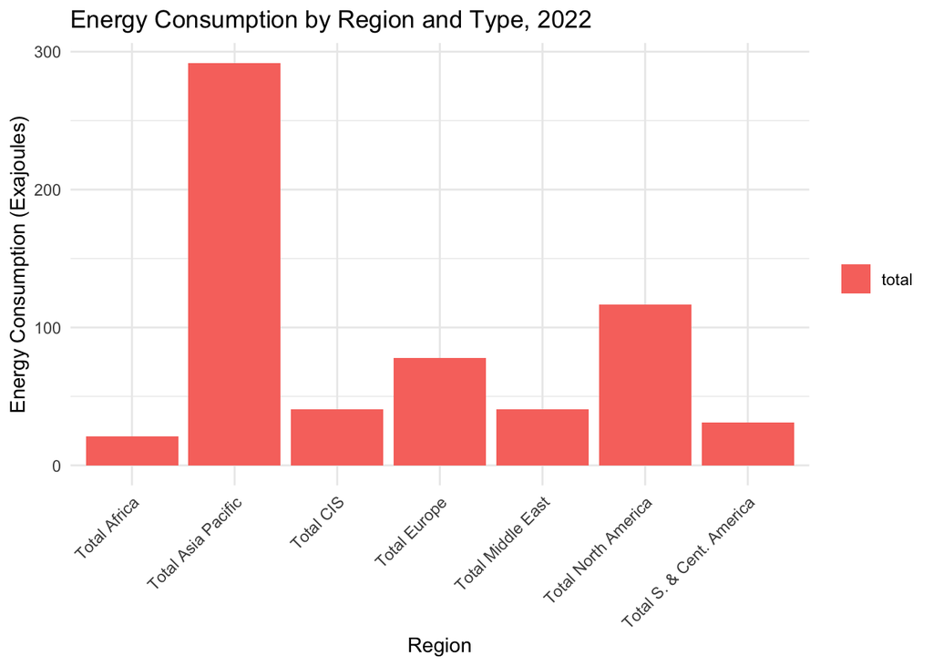

```r
# look at total energy consumption by region of the world
total_plot <- ggplot(total_use, aes(x = country, y = value, fill = energy_type)) +
  geom_col(position = "dodge") +
  theme_minimal() +
  labs(title = "Energy Consumption by Region and Type, 2022",
       x = "Region",
       y = "Energy Consumption (Exajoules)",
       fill = "") +
  theme(axis.text.x = element_text(angle = 45, hjust = 1))

total_plot
```

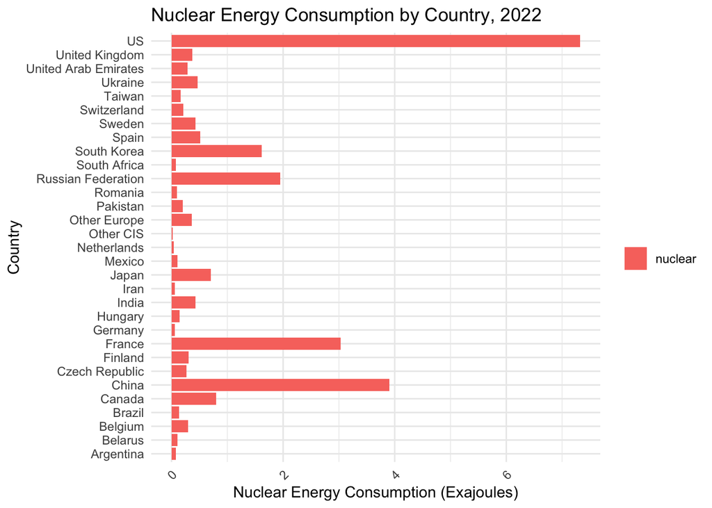

```r
# look at country-specific nuclear energy use
nuclear_plot <- ggplot(nuclear_use, aes(x = country, y = value, fill = energy_type)) +
  geom_col(position = "dodge") +
  theme_minimal() +
  labs(title = "Nuclear Energy Consumption by Country, 2022",
       x = "Country",
       y = "Nuclear Energy Consumption (Exajoules)",
       fill = "") +
  theme(axis.text.x = element_text(angle = 45, hjust = 1)) +
  coord_flip()

nuclear_plot
```

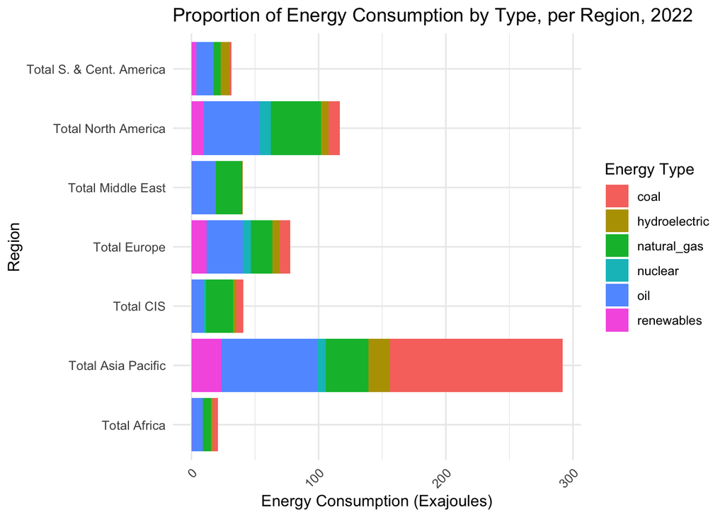

```r
# look at regional energy use
regions_plot <- ggplot(region_use, aes(x = country, y = value, fill = energy_type)) +
  geom_bar(stat = "identity") +
  theme_minimal() +
  labs(title = "Proportion of Energy Consumption by Type, per Region, 2022",
       x = "Region",
       y = "Energy Consumption (Exajoules)",
       fill = "Energy Type") +
  theme(axis.text.x = element_text(angle = 45, hjust = 1)) +
  coord_flip()

regions_plot
```

1. What have you learned about your data? Have any potentially interesting patterns emerged?

2. In HW #1, you outlined some questions that you wanted to answer using these data. Have you made any strides towards answering those questions? If yes, how so? If no, what next steps do you need to take (e.g. I need to create X plot type, I still need to track down Y data, I need to restructure existing data so that you can visualize it in Z ways, etc.)?

I have made some strides toward answering simple questions around nuclear energy, but there is much more to do still. I need to track down other type of information about nuclear energy. I was initially working with a very small data set about nuclear power plant permit applications in the U.S. While I still think that dataset is relevant, I see that there are many, many factors that make up the true cost of nuclear energy (nuclear accidents included). I imagine these factors being presented in clever ways in my infographic by using nuclear power plant- related images and glueing them together! As you will see, my data exploration is of a data set that I had not found at the time of submitting HW1. This is because I have found more robust ones that the smaller data sets can compliment, rather than the other way around. For example, I also found a data set that counts the amount of nuclear power facilities near Native American reservations.

3. What challenges do you foresee encountering with your data? These can be data wrangling and / or visualization challenges.

I think the biggest challenge for my infographic will be to find a way to make all the factors that make up my research question come together cohesively. I imagine perhaps creating a type of “roadmap” that takes the reader through the different pieces of information (power plants near reservations, permit applications, start-up costs etc). I will need these to come together to tell one story and to do so while making it easy for the reader to follow and understand. It is exciting to think about all the possibilities!